# Lab 3 - Moderation

Structural Equation Modeling ED 216F - Instructor: Karen Nylund-Gibson

Adam Garber

April 17, 2020

# 1 Lab preparation

## 1.1 $\color{purple}{\text{Creating a version-controlled R-Project with Github}}$

Download repository here: $\color{blue}{\text{https://github.com/garberadamc/SEM-Lab3}}$

On the Github repository webpage:

1. `fork` your own `branch` of the lab repository
2. copy the repository web URL address from the `clone or download` menu

Within R-Studio:

3. click “NEW PROJECT” (upper right corner of window)
4. choose option `Version Control`
5. choose option `Git`
6. paste the repository web URL path copied from the `clone or download` menu on Github page
7. choose location of the R-Project ($\color{red}{\text{too many nested folders will result in filepath error}}$)

## 1.2 Data source for example 1:

The first example utilizes the *Vocabulary and Education* dataset from the National Opinion Research Center General Social Survey. GSS Cumulative Datafile 1972-2016 (Fox, 2008) [$\color{blue}{\text{See documentation here}}$](https://vincentarelbundock.github.io/Rdatasets/doc/carData/Vocab.html)

This dataset is available via the R-package {`carData`} and can be directly loaded into the R environment.

**Note:** All models specified in the following exercise are for demonstration only and are **not** theoretically justified or valid.

```r
# equatiomatic is not yet on CRAN. Install the development version from GitHub with
remotes::install_github("datalorax/equatiomatic", force = TRUE)
```

```r
library(tidyverse)
library(MplusAutomation)
library(rhdf5)
library(here)
library(gt)
library(gtsummary)
library(estimatr)
library(kableExtra)
library(hrbrthemes)
library(equatiomatic)
library(effects)
library(carData)
library(Ecdat)
library(huxtable)
library(flair)
```

# 2 Begin lab 2 exercise

Read the dataframe into your R-environment from package {`carData`}

```r
data(Vocab)

vocab <- as.data.frame(Vocab)
```

Take a look at focal variables, make a `tribble` table

| Name | Labels |
| --- | --- |
| year | Year of the survey |
| sex | Sex of the respondent (Female or Male) |
| education | Education, in years |
| vocabulary | Vocabulary test score: number correct on a 10-word test |

check some basic descriptives with the {`gtsummary`} package

```r
table1 <- tbl_summary(vocab,
                      statistic = list(all_continuous() ~ "{mean} ({sd})"),
                      missing = "no" ) %>%
  bold_labels()

table1
```

| **Characteristic** | **N = 30351**<sup>1</sup> |
| --- | --- |
| year | 1995 (13) |
| sex |  |
| Female | 17148 (56%) |
| Male | 13203 (44%) |
| education | 13.0 (3.0) |
| vocabulary | 6.00 (2.12) |

<sup>*1*</sup> Statistics presented: mean (SD); n (%)

Run a regression of the model with interaction of `sex` and `education` using the `lm` function

```
m1_interact <- lm(formula =
                           vocabulary ~ sex +
                                  education +
                              sex:education ,
                  data=vocab)
```

Print summary of regression output using package {`huxtable`}

```r
huxreg(m1_interact, error_pos = 'right')
```

|  | (1) |  |
| --- | --- | --- |
| (Intercept) | 1.788 *** | (0.064) |
| sexMale | -0.277 ** | (0.094) |
| education | 0.329 *** | (0.005) |
| sexMale:education | 0.008 | (0.007) |
| N | 30351 |  |
| R2 | 0.231 |  |
| logLik | -61825.557 |  |
| AIC | 123661.113 |  |
| *** p < 0.001; ** p < 0.01; * p < 0.05. |  |  |

Print the Latex syntax for the regression equation using the package {`equatiomatic`}

```r
extract_eq(m1_interact)
```

$$\color{#FF851B}{\text{vocabulary}} = \alpha + \beta_{1}(\color{#0074D9}{\text{sex}_{\text{Male}}}) + \beta_{2}(\color{#2ECC40}{\text{education}}) +
\beta_{3}(\color{#0074D9}{\text{sex}_{\text{Male}}} \times \color{#2ECC40}{\text{education}}) + \epsilon$$

```r
extract_eq(m1_interact, use_coefs = TRUE)
```

$$\color{#FF851B}{\text{vocabulary}} = 1.79 - 0.28(\color{#0074D9}{\text{sex}_{\text{Male}}}) + 0.33(\color{#2ECC40}{\text{education}}) + 0.01(\color{#0074D9}{\text{sex}_{\text{Male}}} \times \color{#2ECC40}{\text{education}}) + \epsilon$$

Plot the interaction effect using the package {`effects`}

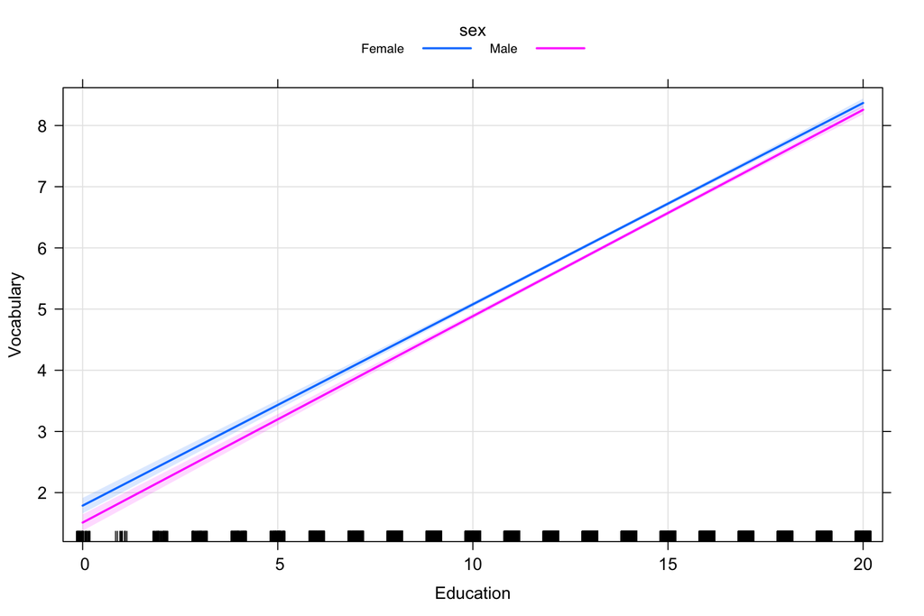

```r
int <- effect("sex:education",m1_interact)

plot(int, main="", grid=TRUE,
x.var = "education", xlab="Education",
ylab="Vocabulary", multiline=TRUE, confint=list(style="auto"))
```

*Figure*. Example 1 interaction is non-significant (no moderation)

Filter year to include 1974 and 2016 (emphasizing moderation effect)

```r
vocab2 <-  vocab %>%
  filter(year %in% c(1974, 2016)) %>%
  mutate(year = droplevels(factor(year)))
```

Run regression with interaction between `year` and `education`

```
# below is R-code to center covariate 'education'
# vocab2 <- vocab %>%
#   mutate(education = scale(education, scale = FALSE)) %>%
#   mutate(year = scale(year, scale = FALSE))

m2_interact <- lm(formula =
                           vocabulary ~ sex +
                                  education +
                                       year +
                             year:education ,
                  data=vocab2)

huxreg(m2_interact, error_pos = 'right')
```

|  | (1) |  |
| --- | --- | --- |
| (Intercept) | 1.600 *** | (0.184) |
| sexMale | -0.073 | (0.062) |
| education | 0.375 *** | (0.015) |
| year2016 | 0.373 | (0.272) |
| education:year2016 | -0.078 *** | (0.021) |
| N | 3307 |  |
| R2 | 0.244 |  |
| logLik | -6607.022 |  |
| AIC | 13226.043 |  |
| *** p < 0.001; ** p < 0.01; * p < 0.05. |  |  |

Print the Latex syntax for the regression equation using the package {`equatiomatic`}

```r
extract_eq(m2_interact)
```

$$\color{#FF851B}{\text{vocabulary}} = \alpha + \beta_{1}(\color{#0074D9}{\text{sex}_{\text{Male}}}) + \beta_{2}(\color{#2ECC40}{\text{education}}) + \beta_{3}(\color{#39CCCC}{\text{year}_{\text{2016}}}) + \beta_{4}(\color{#2ECC40}{\text{education}} \times \color{#39CCCC}{\text{year}_{\text{2016}}}) + \epsilon$$

```r
extract_eq(m2_interact, use_coefs = TRUE)
```

$$\color{#FF851B}{\text{vocabulary}} = 1.6 - 0.07(\color{#0074D9}{\text{sex}_{\text{Male}}}) + 0.38(\color{#2ECC40}{\text{education}}) + 0.37(\color{#39CCCC}{\text{year}_{\text{2016}}}) - 0.08(\color{#2ECC40}{\text{education}} \times \color{#39CCCC}{\text{year}_{\text{2016}}}) + \epsilon$$

Plot the interaction effect using the package {`effects`}

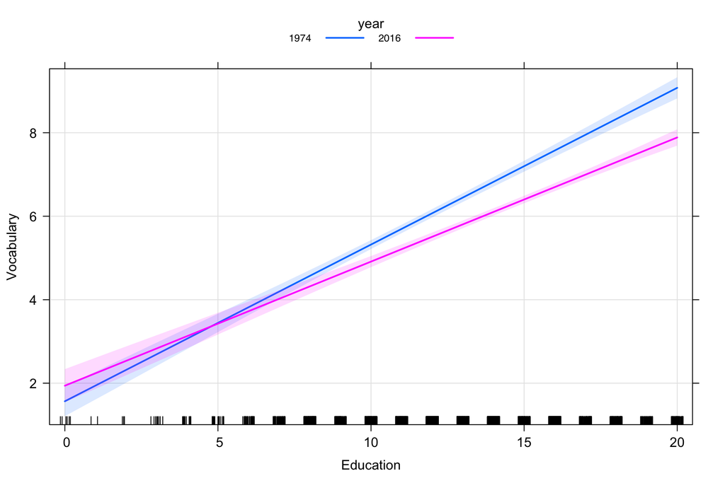

```r
int2 <- effect("education:year", m2_interact)

plot(int2, main="", grid=TRUE,
x.var = "education", xlab="Education",
ylab="Vocabulary",
multiline=TRUE,
confint=list(style="auto"))
```

*Figure*. Example 2 interaction term is significant (moderation)

## 2.1 Estimate moderation example 1

1. covariate: Years of education (`education`)
2. moderator: Year of the survey with 2-levels 1974 and 2016 (`year`)
3. outcome: Vocabulary test score - number correct on a 10-word test (`vocabulary`)

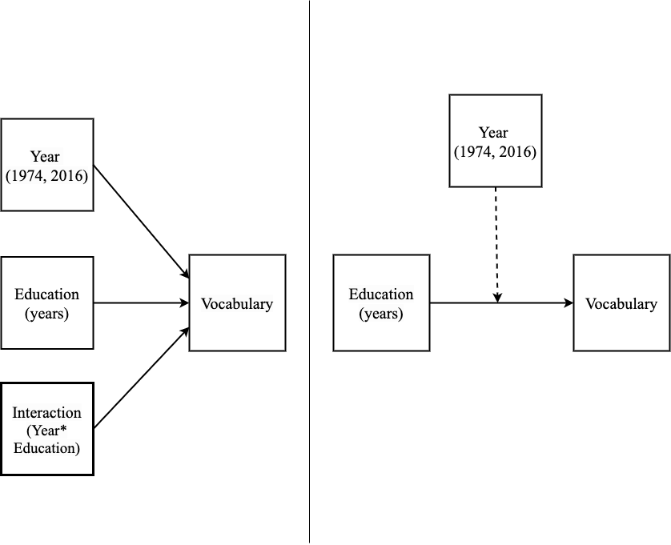

```r
education_2sd <- 2*sqrt(9.85) # 6.28

m1_model  <- mplusObject(
  TITLE = "m5 model indirect - Lab 3",
  VARIABLE =
   "usevar =
    year              ! covariate/moderator
    education         ! covariate
    vocabulary        ! outcome
    int_yred;         ! interaction of year and education",

  DEFINE =
    "center education (grandmean);
     int_yred = year*education;  ! create interaction term ",

  ANALYSIS =
    "estimator = MLR" ,

  MODEL =
   "[vocabulary](b0);
    vocabulary on
    year(b1)
    education(b2)
    int_yred(b3); " ,

  MODELCONSTRAINT =
  "LOOP(x,-1,1,0.01);
   PLOT(y1974 y2016);
   new(hi_y1974 lo_y1974 hi_y2016 lo_y2016 diff_hi);
   y1974 = b0 + b2*x;
   y2016 = b0 + b1 + (b2+b3)*x;

   hi_y1974 = b0 + b2*(6.28);
   lo_y1974 = b0 + b2*(-6.28);
   hi_y2016 = b0 + b1 + (b2 + b3)*(6.28);
   lo_y2016 = b0 + b1 + (b2 + b3)*(-6.28);
    diff_hi = hi_y2016 - hi_y1974; ",

  OUTPUT = "sampstat standardized modindices (3.84)",

  PLOT = "type=plot3;",

  usevariables = colnames(vocab2),
  rdata = vocab2)

m1_model_fit <- mplusModeler(m1_model,
                     dataout=here("mplus_files", "Lab3.dat"),
                    modelout=here("mplus_files", "model1_Lab3.inp"),
                    check=TRUE, run = TRUE, hashfilename = FALSE)
```

## 2.2 Create the simple slope plot from Mplus model output

Extract the output parameters generated using the `model constraint`

```r
 simp_slope <- data.frame(m1_model_fit[["results"]][["parameters"]][["unstandardized"]]) %>%
   filter(paramHeader == "New.Additional.Parameters")  %>%
   filter(param!= "DIFF_HI") %>%
   select(param, est, se) %>%
   mutate(year = case_when(
      param %in% c("HI_Y1974", "LO_Y1974") ~ "1974",
      param %in% c("HI_Y2016", "LO_Y2016") ~ "2016")) %>%
   mutate(education = case_when(
      param %in% c("HI_Y1974", "HI_Y2016") ~ 6.28,
      param %in% c("LO_Y1974", "LO_Y2016") ~ -6.28))
```

Plot the interaction effect with `ggplot` using theme from {`hrbrthemes`} package

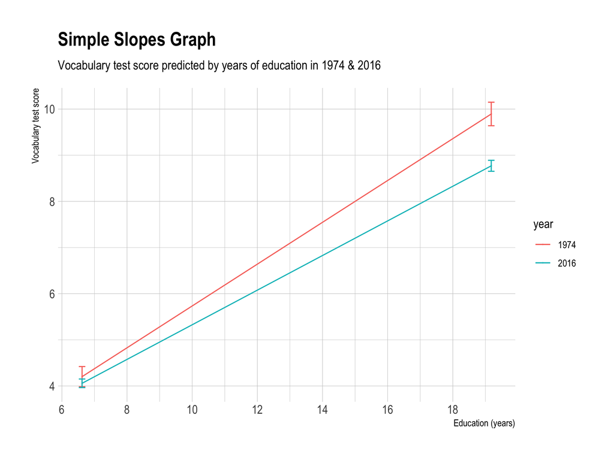

```r
# un-center 'education' so values on x-axis are on the original scale
plot_data <- simp_slope %>% mutate(education = education + 12.9)

ggplot(plot_data, aes(x=education, y=est, color=year, group=year)) +
  geom_point(size=0) +
  geom_line() +
  geom_errorbar(aes(ymin=est-se, ymax=est+se),
                width=.2) +
  scale_x_continuous(breaks = c(seq(6,20,2))) +
  labs(title = "Simple Slopes Graph",
       subtitle = "Vocabulary test score predicted by years of education in 1974 & 2016",
           x = "Education (years)",
           y = "Vocabulary test score") +
  theme_ipsum()

ggsave(here("figures", "m1_simple_slope.png"), height = 6, width = 8)
```